# R Notebook

## 1.4 - Descomposición de la serie (multiplicativa)

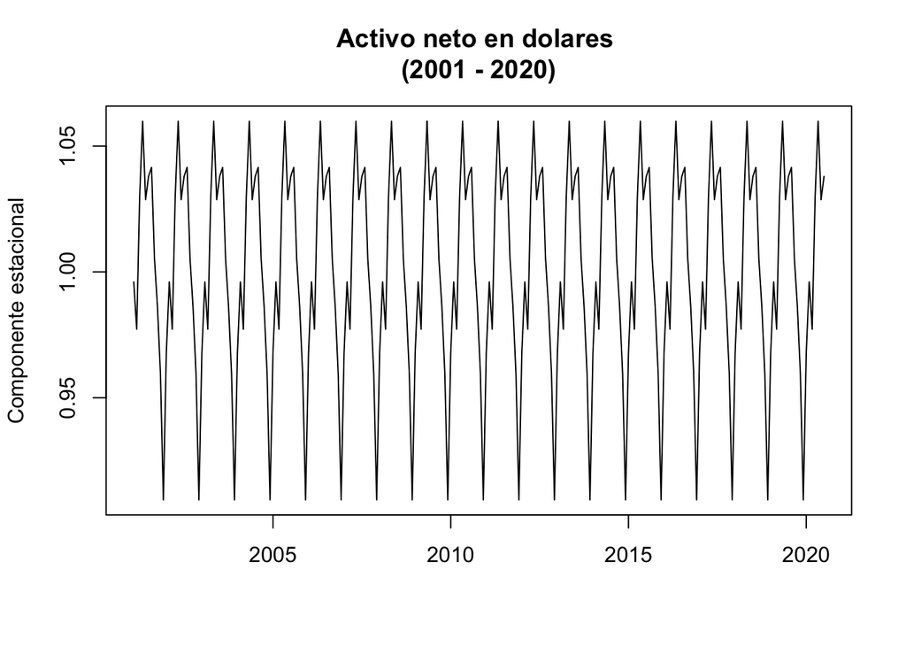

```r
decompose_dolares_full2 = decompose(dolares_ts_full, "multiplicative")

plot(as.ts(decompose_dolares_full2$seasonal), xlab="", ylab="Componente estacional", main= "Activo neto en dolares \n(2001 - 2020)")
```

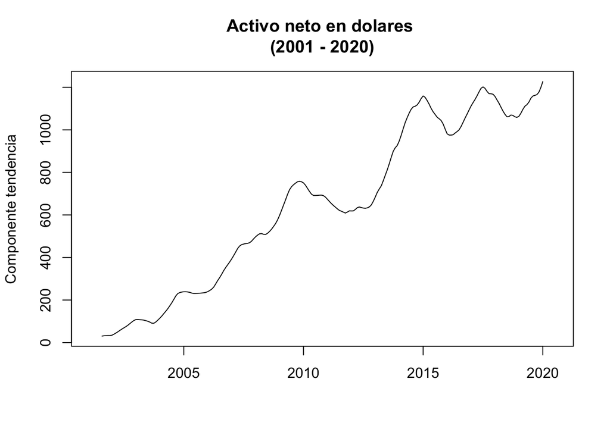

```r
plot(as.ts(decompose_dolares_full2$trend), xlab="", ylab="Componente tendencia",  main= "Activo neto en dolares \n(2001 - 2020)")
```

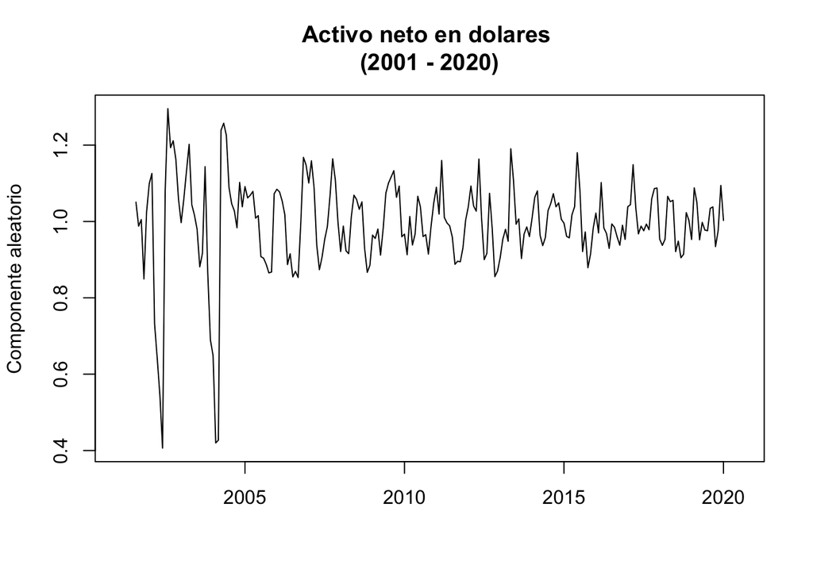

```r
plot(as.ts(decompose_dolares_full2$random), xlab="", ylab="Componente aleatorio",  main= "Activo neto en dolares \n(2001 - 2020)")
```

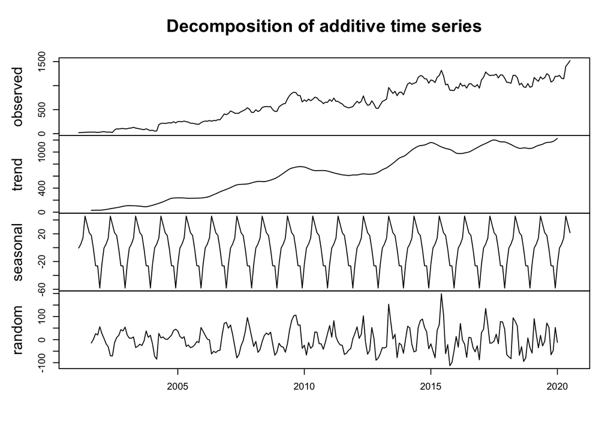

```r
plot(decompose_dolares_full, xlab="")
```

Con respecto a la parte estacional y de tendencia se puede concluir lo mismo que en el caso aditivo pero el componente aleatorio posee demasiadas fluctuaciones al inicio de la serie con lo cual parece ser que es mas bien aditiva. La serie, por ende, se va a analizar de forma aditiva.

## 1.5 - Histograma y test de normalidad para los errores

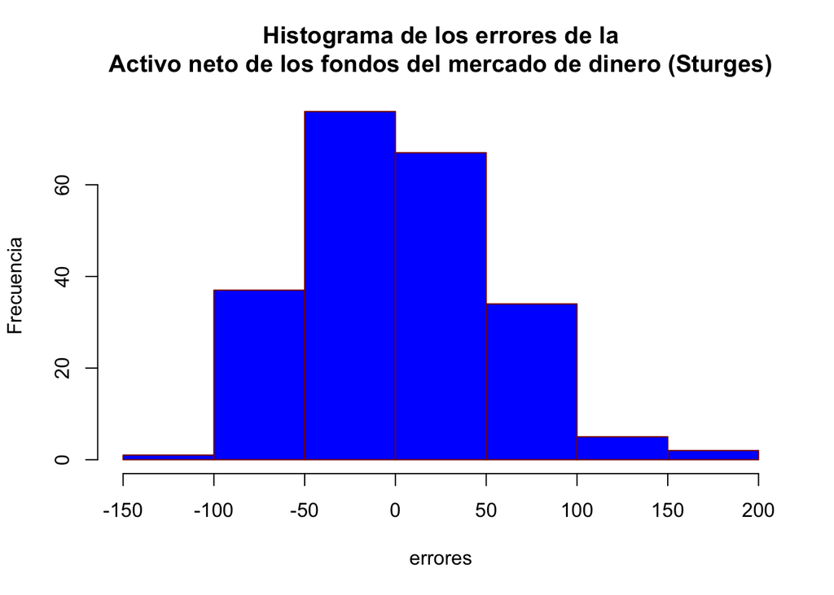

```r
# Accidentes aditivo
errores <- decompose_dolares_full$random

hist(errores,breaks="Sturges",freq=T, include.lowest = TRUE, col="blue",border="darkred", ylab = "Frecuencia", main = "Histograma de los errores de la\nActivo neto de los fondos del mercado de dinero (Sturges)")
```

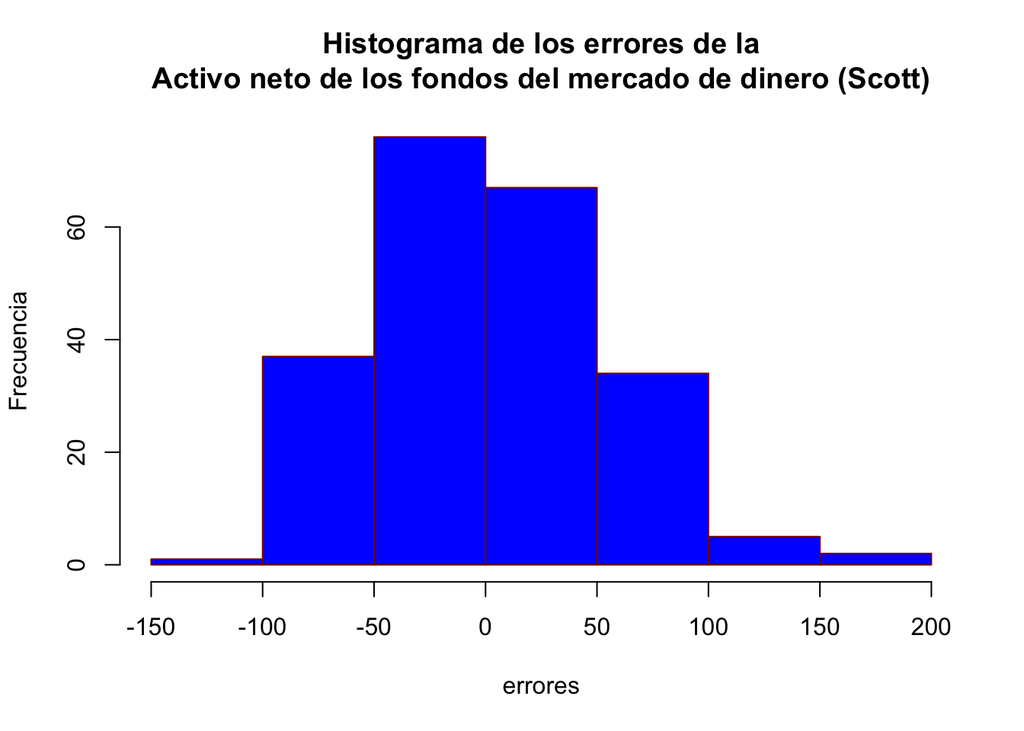

```r
hist(errores,breaks="Scott",freq=T, include.lowest = TRUE, col="blue",border="darkred", ylab = "Frecuencia", main = "Histograma de los errores de la\nActivo neto de los fondos del mercado de dinero (Scott)")
```

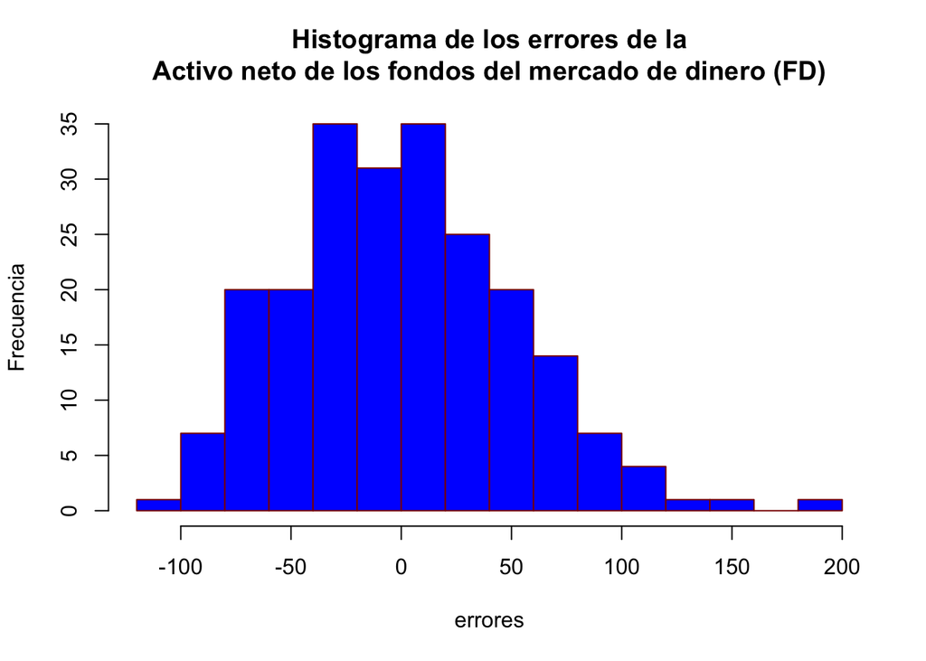

```r
hist(errores,breaks="FD",freq=T, include.lowest = TRUE, col="blue",border="darkred", ylab = "Frecuencia", main = "Histograma de los errores de la\nActivo neto de los fondos del mercado de dinero (FD)")
```

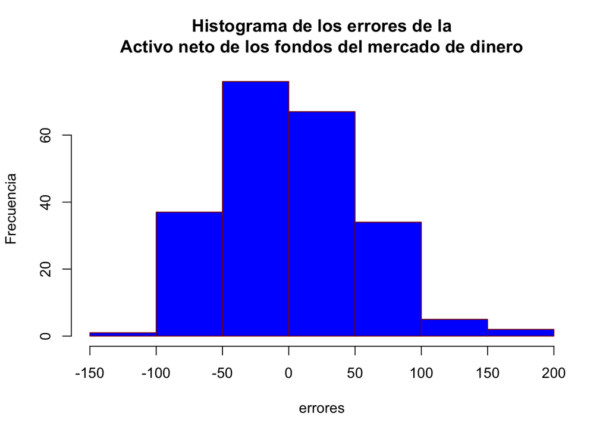

```r
hist(errores,freq=T, include.lowest = TRUE, col="blue",border="darkred",nclass=10, ylab = "Frecuencia", main = "Histograma de los errores de la\nActivo neto de los fondos del mercado de dinero")
```

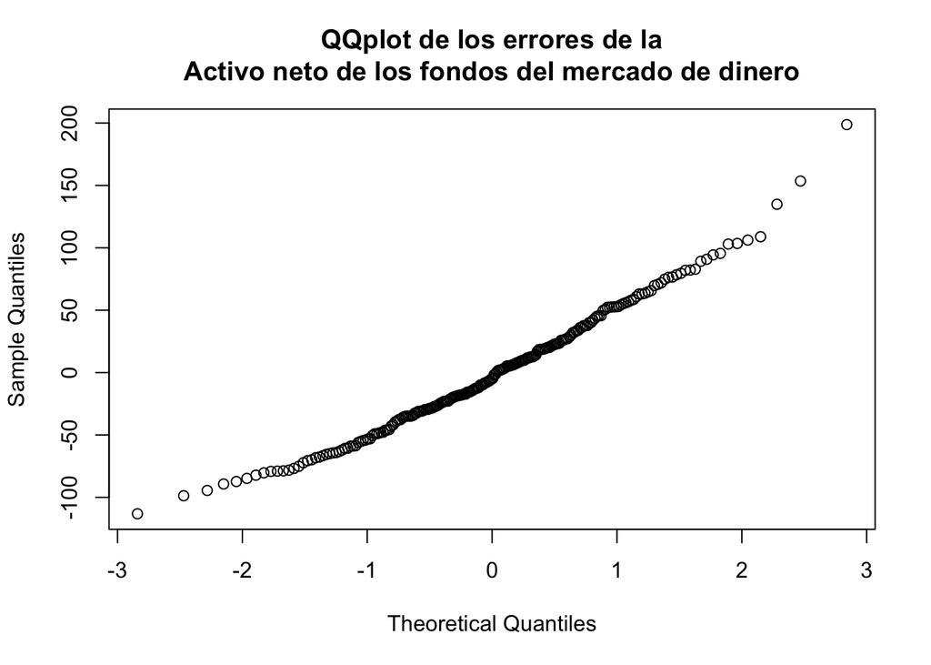

```r
qqnorm(errores, main = "QQplot de los errores de la\nActivo neto de los fondos del mercado de dinero")
```

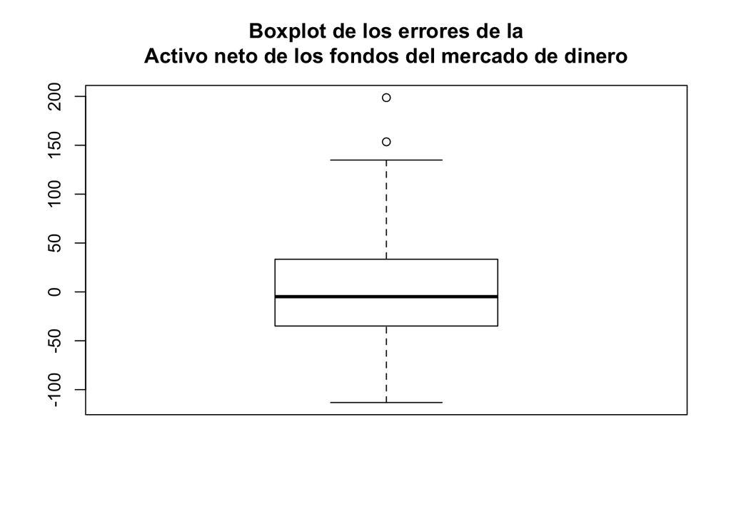

```r
boxplot(errores, main = "Boxplot de los errores de la\nActivo neto de los fondos del mercado de dinero")
```

A partir de todos los histogramas (con cortes de forma automático, de Sturges, de Scott y FD) se puede apreciar que la distribución de los errores es aproximadamente normal con media cero. Además, el boxplot y el qqplot aportan mas evidencias visuales de que los residuales se distribuyen de forma normal con media cero. Pero esto debe corroborarse con pruebas de hipótesis formales.